# Realtime Rt

Working with COVID-19 data using a port to Tidyverse of an interesting analysis developed in Python Scipy

Alexander Carlton

2020-05-02, Updated 2020-11-02

Note: Kevin Systrom has since evolved his model to utilize far more involved tools, notably reworking the entire project to now be based on a [Markov chain Monte Carlo](https://en.wikipedia.org/wiki/Markov_chain_Monte_Carlo) method. Systrom’s continuing work has been available in [a Github repository](https://github.com/k-sys/covid-19), but the origination for this side-project forked off of [an early version](https://github.com/k-sys/covid-19/blob/6beee9dac0a627da609537c9f3c59484f7fdb054/Realtime%20R0.ipynb) which I had found after stumbling across [a port to tidyverse by Ramnath Vaidyanathan](https://colab.research.google.com/drive/1iV1eRHaxirA--kmGIGbR1D67t8z8dUWN#scrollTo=wkFqlgDbgyZK). As always, I am indebted to my sources, and the reader is advised at assume that all the wisdom below comes from their insight, and any mistakes below are all mine.

One of the more approachable models coming out of COVID-19 analyses has been the [rt.live](https://rt.live/) project by Kevin Systrom. Systrom is a software guy, someone who studied virology not to understand biology but to understand the viral growth patterns of internet startups, so this approach may not be authoritative amongst the epidemiologists, but it does offer an interesting opportunity to view and appreciate the available case data.

In the context of [neat and tidy](https://www.fisodd.com/code/neat-and-tidy/) this origin served as an interesting example of how to use a [tidyverse](https://www.tidyverse.org/) approach to mimic and then adapt a model originally developed with Python using Scipy. These analyses adapted well to the tidyverse, offering a good example of one way to do a lot of computation within a neat and tidy approach.

# Realtime Rt

For background, read [The Metric We Need To Manage](http://systrom.com/blog/the-metric-we-need-to-manage-covid-19/)

The insight behind this project is that Bayesian statistics offers useful tools for appreciating the information behind what is published as case data, the daily counts of cases found for this disease. Notably, by working with the available counts of new infections each day it is possible to get some ideas about what is the effective reproduction rate, $R_t$, a measure for that point in the epidemic of how additional infections (on average) come from each infected person. Values of this $R_t$ notably above 1.0 suggest that each infection leads to an increase of cases in the future, and values below 1.0 suggest that only some of the cases today will result in a new infection in the future and hence the epidemic may be easing.

Specifically, Kevin Systrom cites a paper from [a 2008 analysis of the avian flu](https://journals.plos.org/plosone/article?id=10.1371/journal.pone.0002185) that offers a Bayesian equation for estimating $R_t$, the effective reproduction rate, based on the available reports of cases of infection. As Systrom restates in the terminology of this analysis,
$$\lambda = k_{t-1}e^{\gamma(R_t-1)}$$
Or in words, the Bayesian $\lambda$ can be understood as related to a calculation using yesterday’s rate of new cases and $R_t$ value.

## Setup

### Configuration

The serial interval is not an easy value to know. The right value can be difficult for experts to determine. In the early revisions Kevin Systrom references [one paper](https://wwwnc.cdc.gov/eid/article/26/6/20-0357_article) to support his use of a serial interval of 4, then in later updates he references [another paper](https://wwwnc.cdc.gov/eid/article/26/7/20-0282_article) to support his use of 7 for the serial interval. This project is mostly interested in comparative charts rather than predictive accuracy so for this work we will note that these guesses regarding the actual serial interval are going to change the magnitude of peaks and valleys of the charts without making other notable changes to the shapes of the curves.

The key value for the calculation is this aforementioned $\gamma$, the reciprocal of what is known as the serial interval, which is the number of days (on average) between an individual gets infected with this virus and when that individual is in turn infecting others.

```r
# Serial Interval (avg days between being exposed until exposing others)
SD <- 7

# Gamma is 1/serial interval -- this value is used in the equations
GAMMA <- 1/SD
```

The calculations will evaluate likelihoods over a range of possible values for $R_t$. This code uses a vector of values from 0 up through a `R_T_MAX` value. If that constant is too low then we may not evaluate the most likely values for $R_t$, and hence the reported estimates may be far from the right answers. If that value is too high then notable time will be spend evaluating potential values which are not helping at all to improve the accuracy of the work. The best values for `R_T_MAX` would be only somewhat higher than what is eventually discovered to be the most likely values for $R_t$.

```r
# r_t_range is a vector of possible values for R_t
R_T_MAX <- 6
r_t_range <- seq(0, R_T_MAX, length = R_T_MAX*100 + 1)
```

This code also uses a few variables to control some other aspects of the calculations. Most of these serve mainly to improve the aesthetics of the resulting charts. It is worth noting that the choice to smooth the inputs across the variations of a week’s worth of reporting does stabilize the curves significantly, especially since the calculations using this $\lambda$ are not simple when there are days with zero reported new cases.

```r
# WINDOW is how long to smooth over (in days)
# ... 1 week covers weekend (lack of) reporting
WINDOW <- 7
# Note: used in both smoothing the input data
# .. and as the the amount of time to include when estimating R_t

# MIN_CASES is to skip past the uncertain starting periods
MIN_CASES <- 3
# Choose a value large enough to get past when cases were rare and sporatic
# ... will cause the resulting lines on the chart start a bit later
# ... but may avoid some periods of absurdly high variance

# Depending on the data used, choice of dates may clean up charts
FIRST_DATE = "2020-03-02"
LAST_DATE = "2020-05-02"
```

### Environment

```r
library(tidyverse)
library(lubridate)
library(smoother)
library(geofacet)
library(slider)
```

The `tidyverse` is used for most of the heavy lifting here.

The `smoother` library offers a clean way to smooth our inputs within a single line in a `mutate()` call.

The `slider` library is a recent addition to my workflow, added because it provides a nice and clean method to control just how I want my sliding windows to work.

And `lubridate` just because it’s really handy to work in `days()` rather than “rows”…

Finally, `geofacet` is used to improve the layout of the display.

This implementation will take advantage of the data provided by the CSSE folks at Johns Hopkins, the same data used for the other Neat-and-Tidy bits.

The Neat-and-Tidy project keeps the [Johns Hopkins CSSE COVID-19 data](https://github.com/CSSEGISandData/COVID-19) in a “COVID-19” subdirectory. Also, since the the Johns Hopkins US data is supplied at the county level, for simplication we sum up the county-level data to get statewide totals.

```r
jhu_directory <- "COVID-19/csse_covid_19_data/csse_covid_19_time_series/"
jhu_states_filename <- "time_series_covid19_confirmed_US.csv"
jhu_states_cols <- cols(
    .default = col_double(),
    UID = col_character(),
    iso2 = col_character(),
    iso3 = col_character(),
    FIPS = col_character(),
    Admin2 = col_character(),
    Province_State = col_character(),
    Country_Region = col_character(),
    Combined_Key = col_character()
)

input_data <- read_csv(
    paste0(jhu_directory, jhu_states_filename),
    col_types = jhu_states_cols
) %>%
    select(
        -UID, -iso2, -iso3, -code3, -Lat, -Long_, -FIPS,
        -Combined_Key
    ) %>%
    rename(
        State = "Province_State",
        Country = "Country_Region"
    ) %>%
    pivot_longer(
        -c(Admin2, State, Country),
        names_to = "date_str",
        values_to = "cases"
    ) %>%
    filter(State %in% state.name) %>%
    group_by(State, date_str) %>%
    summarise(
        total = sum(cases),
        .groups = "drop_last"
    ) %>%
    mutate(
        entity = State,
        date = as.Date(date_str, "%m/%d/%y"),
        cases = total
    ) %>%
    ungroup() %>%
    select(-State, -date_str, -total)
```

## Some Functions

The `prepare_data()` function is called once on the data after it has been loaded. basically this is where we “smooth” the data to avoid the differences between weekend and weekday reports. This function also weeds out parts of the data that are a) to old, b) too few, c) too short to be worth processing.

```r
prepare_data <- function(data) {
    # given a tibble with "date", "entity", and "cases"
    # return a tibble adding "new": difference between day and day-before
    # ... and adding "value": gaussian smoothed values of new, rounded

    if (exists("FIRST_DATE") && !is.null(FIRST_DATE)) {
        data <- data %>%
            filter(date >= FIRST_DATE)
    }
    if (exists("LAST_DATE") && !is.null(LAST_DATE)) {
        data <- data %>%
            filter(date <= LAST_DATE)
    }
    if (exists("MIN_CASES") && !is.null(MIN_CASES)) {
        data <- data %>%
            filter(cases > MIN_CASES)
    }
    data %>%
        group_by(entity) %>%
        # Find and drop entities with too few dates
        mutate(len = length(date)) %>%
        filter(len > WINDOW) %>%
        # Sort by date to support a smoothing window
        arrange(date) %>%
        mutate(
            # diff() returns n-1 items, hack in an initial value...
            new = c(cases[1], diff(cases)),
            # Gaussian smoother rounded back to discrete values
            k = round(
                smth.gaussian(new, window = WINDOW, tails = TRUE)
            )
        ) %>%
        ungroup() %>%
        select(-len)
}
```

The `compute_likelihood()` function is called to generate likelihood probabilities for each date in the data across all the values of $R_t$ we think are worth evaluating. We make a separate call to this function for each set of location data, so one entity at a time, which does simplify some of the `group_by()` calls.

```r
compute_likelihood <- function(data) {
    # given a tibble with "date" and "value" (smoothed case values)
    # return a tibble of likelihoods

    data %>%
        arrange(date) %>%
        crossing(val = r_t_range) %>%
        group_by(val) %>%
        mutate(
            lag = lag(k, 1),
            lambda = lag(k, 1) * exp(GAMMA * (val - 1)),
            log_likelihood_r_t = dpois(k, lambda, log = TRUE)
        ) %>%
        filter(
            # drop first date since its lamda value is weak
            date > min(date)
        ) %>%
        ungroup() %>%
        select(
            -lambda
        )
}
```

The `compute_posterior()` function uses the likelihood probabilities to calculate posterior values. Note: there is a bit of arithmetic trickery below, this code uses a sum of log values rather than a product of the base values.

```r
compute_posterior <- function(data) {
    # Given a tibble with "date" and "log_likelihood_r_t"
    # return a tibble with posteriors

    data %>%
        arrange(date) %>%
        group_by(val) %>%
        mutate(
            posterior = exp(
                slide_index_dbl(
                    log_likelihood_r_t,
                    date,
                    sum,
                    .before = days(WINDOW - 1),
                    .complete = FALSE
                )
            )
        )
}
```

The `calc_interval()` function is not very “R like”, but it gets the job relatively effectively. This is a quick-and-dirty utility function to run through a vector of probabilities in order to find a reasonably small interval that covers the specified interval.

```r
calc_interval <- function(vals, probs, ci=0.95) {
    # Given a vector of values and it's vector of probabilities
    # return a list of most-likely value and a hi/lo interval

    # We find a reasonable interval, not the optimal interval
    # ... but this method runs within linear time

    sum <- sum(probs, na.rm = TRUE)
    if (sum == 0) {
        # then we have a problem, there are no probabilities...
        # so, return all zeros...
        ml <- 0
        lo <- 0
        hi <- 0
    } else {
        # key: use an array of cumulative sum of normalized values, so
        # difference in values between two points is the interval there
        cum <- cumsum(probs / sum)
        len <- length(cum)

        # start looking at the point of maximal probability
        idx_ml <- which.max(probs)
        idx_lo <- idx_ml
        idx_hi <- idx_ml

        for (count in 1:len) {
            # How big an interval do we have so far?
            sum <- cum[idx_hi] - cum[idx_lo]
            if (sum >= ci) {
                # We've found an interval wide enough, stop looking
                break
            }

            # not wide enough yet, expand the interval one step
            if (idx_lo == 1) {
                # can't go lower, must go higher
                if (idx_hi == len) {
                    # but can't go higher, we're done
                    break
                } else {
                    idx_hi <- idx_hi + 1
                }
            } else {
                if (idx_hi == len) {
                    # can't go higher, so step open lower
                    if (idx_lo == 1) {
                        # but also already at bottom, we're done
                        break
                    } else {
                        idx_lo <- idx_lo - 1
                    }
                } else {
                    # both directions are possible...
                    # be greedy, check which direction gives us more
                    nxt_lo <- idx_lo - 1
                    nxt_hi <- idx_hi + 1
                    gap_lo <- probs[nxt_lo]
                    gap_hi <- probs[nxt_hi]
                    if (gap_hi > gap_lo) {
                        idx_hi <- nxt_hi
                    }
                    if (gap_lo > gap_hi) {
                        idx_lo <- nxt_lo
                    }
                    if (gap_lo == gap_hi) {
                        # not common save for 0 probabilities, but...
                        # at least go a different direction each time
                        if (count %% 2 == 1) {
                            idx_lo <- nxt_lo
                        } else {
                            idx_hi <- nxt_hi
                        }
                    }
                }
            }
        }
        ml <- vals[idx_ml]
        lo <- vals[idx_lo]
        hi <- vals[idx_hi]
    }

    list("ml" = ml, "lo" = lo, "hi" = hi)
}
```

The final `estimate_rt()` function then becomes the simplest, but we maintain the function abstraction for a regularized workflow. Basically, for each date, call a function to report back the “most likely” value, and either end of a 95% confidence interval.

The likelihood calculations end up with fairly narrow distributions so often even a very high “confidence” levels still result in narrow bands.

```r
estimate_rt <- function(data) {
    # Given a tibble with "date", "entity", and "cases"
    # ... crossed with "r_t" and "posterior"
    # return a tibble adding most_likely and hi/lo estimates for R_t

    data %>%
        group_by(entity, date, cases) %>%
        summarise(
            list = list(calc_interval(val, posterior)),
            r_t_most_likely = list[[1]]$ml,
            r_t_interval_lo = list[[1]]$lo,
            r_t_interval_hi = list[[1]]$hi,
            .groups = "drop_last"
        ) %>%
        select(
            -list
        )
}
```

## Operation

The actual operation then is rather straight forward.

Prep the data, then split the data apart based on the location, and for each split: compute likelihoods and then posteriors and finally grab the most likely values for $R_t$ from the posteriors.

```r
r_t_estimates <- input_data %>%
    prepare_data() %>%
    group_by(entity) %>%
    group_split() %>%
    map_df(~ {
        .x %>%
            compute_likelihood() %>%
            compute_posterior() %>%
            estimate_rt()
    }) %>%
    ungroup()
```

The code above is one example of where a `tidyverse` approach enables a whole lot of calculations to be elegantly expressed.

## Display

Showing results for 50 different states in one visualization often makes for a difficult experience. However, since most of the audience for US data can readily recognize a map of the country, using `geofacet` to layout the charts like a map can help lower the initial cognative load.

Note: `geofacet` supports a wide variety of layouts including support for custom maps. One example of a different US layout is included in the associated article on small multiples.

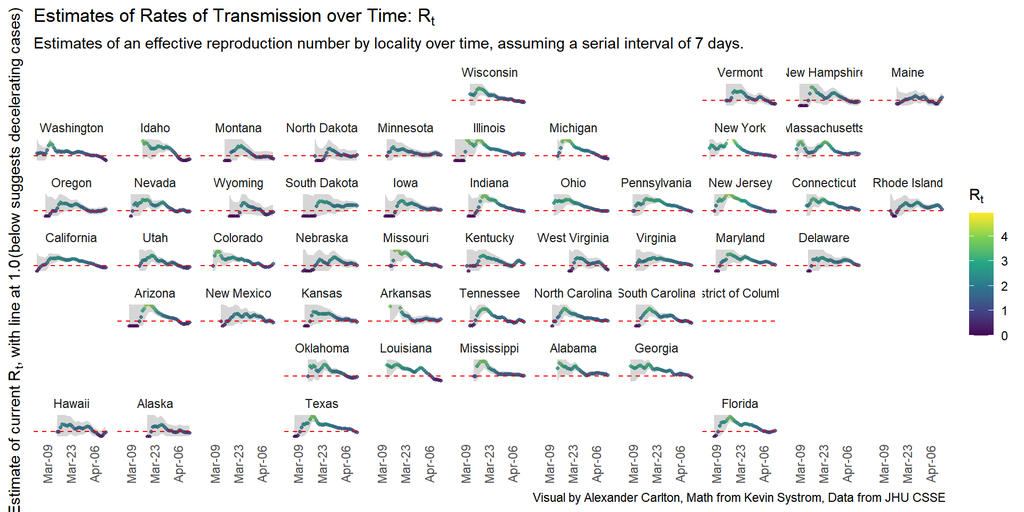

```r
gg <- r_t_estimates %>%
    ggplot(
        aes(
            x = date,
            y = r_t_most_likely,
            color = r_t_most_likely
        )
    ) +
    geom_point(
        size = 0.95,
        alpha = 0.8
    ) +
    scale_color_viridis_c(direction = 1) +
    geom_hline(yintercept = 1, linetype = 'dashed', color = "red") +
    geom_ribbon(
        aes(
            ymin = r_t_interval_lo,
            ymax = r_t_interval_hi,
            color = NULL, group = NULL
        ),
        fill = 'gray20',
        alpha = 0.2
    ) +
    scale_x_date(
        date_breaks = "2 weeks",
        date_labels = "%b-%d"
    ) +
    coord_cartesian(ylim = c(0, 4)) +
    facet_geo(
        ~ entity,
        move_axes = FALSE
    ) +
    guides(
        color = guide_colorbar(title = expression('R'[t]))
    ) +
    labs(
        title = expression('Estimates of Rates of Transmission over Time: R'[t]),
        subtitle = paste(
            "Estimates of an effective reproduction number by locality over time,",
            "assuming a serial interval of",
            SD,
            "days."
        ),
        x = NULL,
        y = expression(paste(
            "Estimate of current R"[t], ", with line at 1.0",
            "(below suggests decelerating cases)"
        )),
        caption = paste(
            "Visual by Alexander Carlton,",
            "Math from Kevin Systrom,",
            "Data from JHU CSSE"
        )
    ) +
    theme_minimal() +
    theme(
        panel.grid.major = element_blank(),
        panel.grid.minor = element_blank(),
        axis.text.y = element_blank(),
        axis.text.x = element_text(angle = 90, vjust = 0.5)
    )

print(gg)
```